# IODS course project

#### Scaling the data

Next I will center and standardize the variables by function scale

```r
boston_scaled <- scale(Boston)
summary(boston_scaled)
```

```
##       crim                 zn               indus              chas
##  Min.   :-0.419367   Min.   :-0.48724   Min.   :-1.5563   Min.   :-0.2723
##  1st Qu.:-0.410563   1st Qu.:-0.48724   1st Qu.:-0.8668   1st Qu.:-0.2723
##  Median :-0.390280   Median :-0.48724   Median :-0.2109   Median :-0.2723
##  Mean   : 0.000000   Mean   : 0.00000   Mean   : 0.0000   Mean   : 0.0000
##  3rd Qu.: 0.007389   3rd Qu.: 0.04872   3rd Qu.: 1.0150   3rd Qu.:-0.2723
##  Max.   : 9.924110   Max.   : 3.80047   Max.   : 2.4202   Max.   : 3.6648
##       nox                rm               age               dis
##  Min.   :-1.4644   Min.   :-3.8764   Min.   :-2.3331   Min.   :-1.2658
##  1st Qu.:-0.9121   1st Qu.:-0.5681   1st Qu.:-0.8366   1st Qu.:-0.8049
##  Median :-0.1441   Median :-0.1084   Median : 0.3171   Median :-0.2790
##  Mean   : 0.0000   Mean   : 0.0000   Mean   : 0.0000   Mean   : 0.0000
##  3rd Qu.: 0.5981   3rd Qu.: 0.4823   3rd Qu.: 0.9059   3rd Qu.: 0.6617
##  Max.   : 2.7296   Max.   : 3.5515   Max.   : 1.1164   Max.   : 3.9566
##       rad               tax             ptratio            black
##  Min.   :-0.9819   Min.   :-1.3127   Min.   :-2.7047   Min.   :-3.9033
##  1st Qu.:-0.6373   1st Qu.:-0.7668   1st Qu.:-0.4876   1st Qu.: 0.2049
##  Median :-0.5225   Median :-0.4642   Median : 0.2746   Median : 0.3808
##  Mean   : 0.0000   Mean   : 0.0000   Mean   : 0.0000   Mean   : 0.0000
##  3rd Qu.: 1.6596   3rd Qu.: 1.5294   3rd Qu.: 0.8058   3rd Qu.: 0.4332
##  Max.   : 1.6596   Max.   : 1.7964   Max.   : 1.6372   Max.   : 0.4406
##      lstat              medv
##  Min.   :-1.5296   Min.   :-1.9063
##  1st Qu.:-0.7986   1st Qu.:-0.5989
##  Median :-0.1811   Median :-0.1449
##  Mean   : 0.0000   Mean   : 0.0000
##  3rd Qu.: 0.6024   3rd Qu.: 0.2683
##  Max.   : 3.5453   Max.   : 2.9865
```

If we now look at the summary table, we can see that the values have changed compared to the original data. All of the mean values are 0, and almost all of the median, 1st Qu, and min values are negative.

```r
boston_scaled <- as.data.frame(boston_scaled) #changing the object to data frame
class(boston_scaled)
```

```
## [1] "data.frame"
```

Next I will create a categorical variable of the crime rate in the Boston dataset (from the scaled crime rate).

```r
summary(boston_scaled$crim)
```

```
##      Min.   1st Qu.    Median      Mean   3rd Qu.      Max.
## -0.419367 -0.410563 -0.390280  0.000000  0.007389  9.924110
```

```r
bins <- quantile(boston_scaled$crim) #creating a quantile vector of crim and printing it
bins
```

```
##           0%          25%          50%          75%         100%
## -0.419366929 -0.410563278 -0.390280295  0.007389247  9.924109610
```

```r
# creating a categorical variable 'crime'
crime <- cut(boston_scaled$crim, breaks = bins, include.lowest = TRUE, label=c("low", "med_low", "med_high", "high"))
table(crime)
```

```
## crime
##      low  med_low med_high     high
##      127      126      126      127
```

```r
boston_scaled <- dplyr::select(boston_scaled, -crim)# removing original crim from the dataset

boston_scaled <- data.frame(boston_scaled, crime)# adding the new categorical value to scaled data

str(boston_scaled) #looking that everything worked
```

```
## 'data.frame':    506 obs. of  14 variables:
##  $ zn     : num  0.285 -0.487 -0.487 -0.487 -0.487 ...
##  $ indus  : num  -1.287 -0.593 -0.593 -1.306 -1.306 ...
##  $ chas   : num  -0.272 -0.272 -0.272 -0.272 -0.272 ...
##  $ nox    : num  -0.144 -0.74 -0.74 -0.834 -0.834 ...
##  $ rm     : num  0.413 0.194 1.281 1.015 1.227 ...
##  $ age    : num  -0.12 0.367 -0.266 -0.809 -0.511 ...
##  $ dis    : num  0.14 0.557 0.557 1.077 1.077 ...
##  $ rad    : num  -0.982 -0.867 -0.867 -0.752 -0.752 ...
##  $ tax    : num  -0.666 -0.986 -0.986 -1.105 -1.105 ...
##  $ ptratio: num  -1.458 -0.303 -0.303 0.113 0.113 ...
##  $ black  : num  0.441 0.441 0.396 0.416 0.441 ...
##  $ lstat  : num  -1.074 -0.492 -1.208 -1.36 -1.025 ...
##  $ medv   : num  0.16 -0.101 1.323 1.182 1.486 ...
##  $ crime  : Factor w/ 4 levels "low","med_low",..: 1 1 1 1 1 1 2 2 2 2 ...
```

I will divide the dataset to train and test sets, so that 80% of the data belongs to the train set.

```r
n <- nrow(boston_scaled)# number of rows in the Boston dataset

ind <- sample(n,  size = n * 0.8)# choosing randomly 80% of the rows

train <- boston_scaled[ind,] # creating train set containing 80 % of the data

test <- boston_scaled[-ind,] # creating test set containing 20 % of the data
```

#### Linear discriminant analysis

Next I will fit the linear discriminant analysis on the train set. I will use the categorical crime rate as the target variable and all the other variables in the dataset as predictor variables.

```r
lda.fit <- lda(crime ~., data = train) # linear discriminant analysis
lda.fit # print the lda.fit object
```

```
## Call:
## lda(crime ~ ., data = train)
##
## Prior probabilities of groups:
##       low   med_low  med_high      high
## 0.2574257 0.2400990 0.2500000 0.2524752
##
## Group means:
##                   zn      indus         chas        nox         rm        age
## low       0.90482377 -0.9641590 -0.196615602 -0.8768685  0.4429322 -0.8915478
## med_low  -0.08830601 -0.3214609  0.011791568 -0.5910446 -0.1209988 -0.3428259
## med_high -0.38365582  0.2261745  0.195445218  0.4332666  0.1422253  0.3954700
## high     -0.48724019  1.0171096 -0.002135914  1.0236542 -0.4071432  0.8077714
##                 dis        rad        tax     ptratio       black        lstat
## low       0.9232974 -0.6770857 -0.7261391 -0.42137983  0.37608387 -0.778782323
## med_low   0.3704334 -0.5497161 -0.4913723 -0.04898463  0.32009896 -0.129838813
## med_high -0.3927972 -0.3996780 -0.2873858 -0.27169592  0.04289363  0.006766907
## high     -0.8472278  1.6382099  1.5141140  0.78087177 -0.81939957  0.877289726
##                  medv
## low       0.515827233
## med_low   0.007081775
## med_high  0.193976859
## high     -0.620235989
##
## Coefficients of linear discriminants:
##                 LD1         LD2         LD3
## zn       0.07531951  0.58355277 -0.84832599
## indus    0.06645844 -0.48866461  0.32898571
## chas    -0.05802077 -0.07820108  0.22072374
## nox      0.38529895 -0.72891885 -1.42861957
## rm      -0.09477568 -0.15654981 -0.19189786
## age      0.23087137 -0.26737122  0.02618536
## dis     -0.04851246 -0.21751606  0.07736177
## rad      3.10187276  0.87705968  0.04165425
## tax      0.08328267  0.18506277  0.31989796
## ptratio  0.12553038 -0.01054656 -0.29799045
## black   -0.12218917  0.01788535  0.13451077
## lstat    0.22034620 -0.19172355  0.33305684
## medv     0.22485064 -0.33942680 -0.27233699
##
## Proportion of trace:
##    LD1    LD2    LD3
## 0.9470 0.0403 0.0128
```

I will draw the LDA (bi)plot, but first we need the function for lda biplot arrows.

```r
lda.arrows <- function(x, myscale = 1, arrow_heads = 0.1, color = "red", tex = 0.75, choices = c(1,2)){
  heads <- coef(x)
  arrows(x0 = 0, y0 = 0,
         x1 = myscale * heads[,choices[1]],
         y1 = myscale * heads[,choices[2]], col=color, length = arrow_heads)
  text(myscale * heads[,choices], labels = row.names(heads),
       cex = tex, col=color, pos=3)
}

classes <- as.numeric(train$crime) # target classes as numeric
```

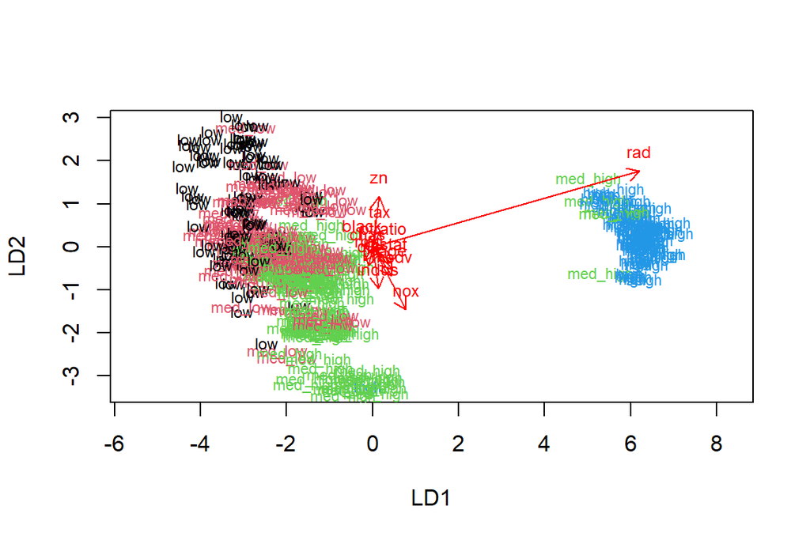

```r
plot(lda.fit, dimen = 2, col = classes, pch = classes)# plotting the lda results
lda.arrows(lda.fit, myscale = 2) #adding the arrows
```

If we look at the model summary and plot, we see that LD1 explains 95 % of the variation in the plot. There is clear cluster in the right side (blue). Rad seems to be significant variable for that. Other colours are not that well separated on the left.

#### Model predictions

Next I will save the crime categories from the test set and then remove the categorical crime variable from the test dataset. Then I will predict the classes with the LDA model on the test data.

```r
correct_classes <- test$crime # saving the correct classes from test data

test <- dplyr::select(test, -crime) # removing the crime variable from test data
```

```r
lda.pred <- predict(lda.fit, newdata = test) # predicting classes with test data

table(correct = correct_classes, predicted = lda.pred$class) # cross tabulating the results
```

```
##           predicted
## correct    low med_low med_high high
##   low       14       7        2    0
##   med_low    5      16        8    0
##   med_high   1      11       12    1
##   high       0       0        0   25
```

If we look at the prediction results, we can see that it works quite well. Predictions are working best in high group.

#### K-means clustering

Reloading the Boston dataset and standardizing.

```r
data(Boston)#reloading the Boston dataset
boston_scaled <- scale(Boston) #scaling
summary(boston_scaled)
```

```
##       crim                 zn               indus              chas
##  Min.   :-0.419367   Min.   :-0.48724   Min.   :-1.5563   Min.   :-0.2723
##  1st Qu.:-0.410563   1st Qu.:-0.48724   1st Qu.:-0.8668   1st Qu.:-0.2723
##  Median :-0.390280   Median :-0.48724   Median :-0.2109   Median :-0.2723
##  Mean   : 0.000000   Mean   : 0.00000   Mean   : 0.0000   Mean   : 0.0000
##  3rd Qu.: 0.007389   3rd Qu.: 0.04872   3rd Qu.: 1.0150   3rd Qu.:-0.2723
##  Max.   : 9.924110   Max.   : 3.80047   Max.   : 2.4202   Max.   : 3.6648
##       nox                rm               age               dis
##  Min.   :-1.4644   Min.   :-3.8764   Min.   :-2.3331   Min.   :-1.2658
##  1st Qu.:-0.9121   1st Qu.:-0.5681   1st Qu.:-0.8366   1st Qu.:-0.8049
##  Median :-0.1441   Median :-0.1084   Median : 0.3171   Median :-0.2790
##  Mean   : 0.0000   Mean   : 0.0000   Mean   : 0.0000   Mean   : 0.0000
##  3rd Qu.: 0.5981   3rd Qu.: 0.4823   3rd Qu.: 0.9059   3rd Qu.: 0.6617
##  Max.   : 2.7296   Max.   : 3.5515   Max.   : 1.1164   Max.   : 3.9566
##       rad               tax             ptratio            black
##  Min.   :-0.9819   Min.   :-1.3127   Min.   :-2.7047   Min.   :-3.9033
##  1st Qu.:-0.6373   1st Qu.:-0.7668   1st Qu.:-0.4876   1st Qu.: 0.2049
##  Median :-0.5225   Median :-0.4642   Median : 0.2746   Median : 0.3808
##  Mean   : 0.0000   Mean   : 0.0000   Mean   : 0.0000   Mean   : 0.0000
##  3rd Qu.: 1.6596   3rd Qu.: 1.5294   3rd Qu.: 0.8058   3rd Qu.: 0.4332
##  Max.   : 1.6596   Max.   : 1.7964   Max.   : 1.6372   Max.   : 0.4406
##      lstat              medv
##  Min.   :-1.5296   Min.   :-1.9063
##  1st Qu.:-0.7986   1st Qu.:-0.5989
##  Median :-0.1811   Median :-0.1449
##  Mean   : 0.0000   Mean   : 0.0000
##  3rd Qu.: 0.6024   3rd Qu.: 0.2683
##  Max.   : 3.5453   Max.   : 2.9865
```

```r
boston_scaled <- as.data.frame(boston_scaled) #changing the object to data frame
class(boston_scaled)
```

```
## [1] "data.frame"
```

I will calculate the distances between the observations and run k-means algorithm on the dataset.

```r
dist_eu <- dist(boston_scaled) # euclidean distance matrix

summary(dist_eu) #summary of the distances
```

```
##    Min. 1st Qu.  Median    Mean 3rd Qu.    Max.
##  0.1343  3.4625  4.8241  4.9111  6.1863 14.3970
```

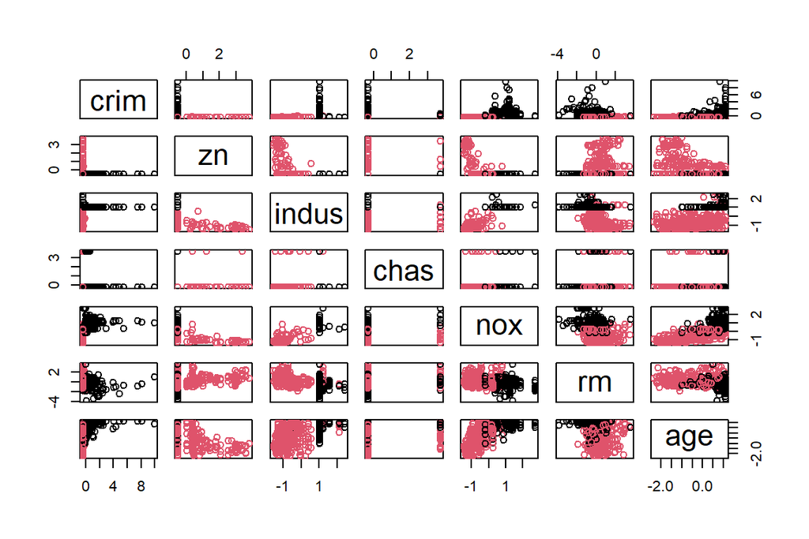

```r
km <-kmeans(boston_scaled, centers = 2) # k-means clustering

pairs(boston_scaled[1:7], col = km$cluster)# plotting the scaled Boston dataset with clusters
```

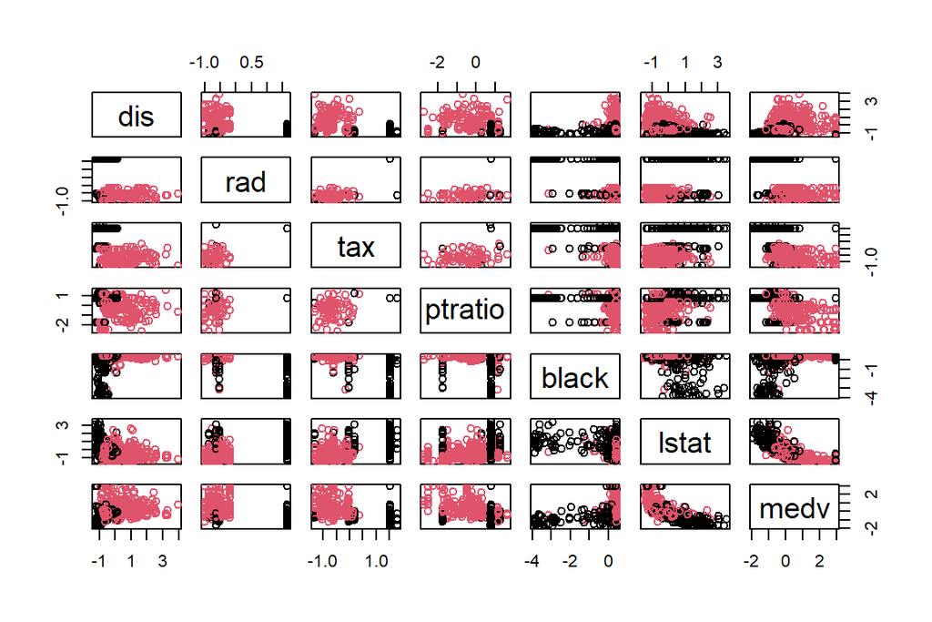

```r
pairs(boston_scaled[8:14], col = km$cluster)# perform plotting in two parts so that plots are easier to look at
```

Next I will investigate what is the optimal number of clusters.

```r
library(ggplot2)
```

```r
set.seed(123)
```

```r
k_max <- 15 #determining the number of clusters
```

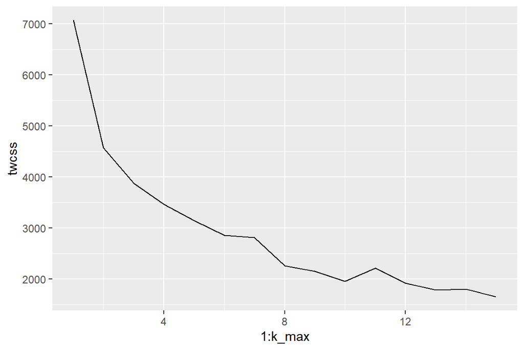

```r
twcss <- sapply(1:k_max, function(k){kmeans(boston_scaled, k)$tot.withinss}) # calculate the total within sum of squares

# visualize the results
qplot(x = 1:k_max, y = twcss, geom = 'line')
```

I will now do the clustering again

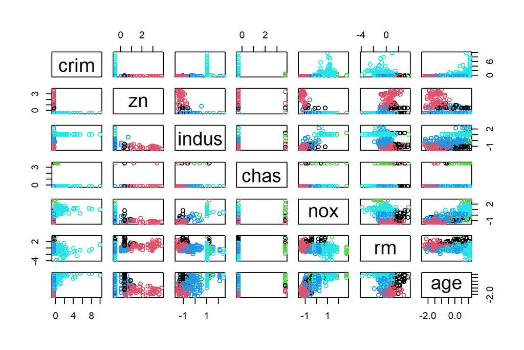

```r
km <-kmeans(boston_scaled, centers = 5) # now 5 centers

pairs(boston_scaled[1:7], col = km$cluster)# plotting the scaled Boston dataset with clusters
```

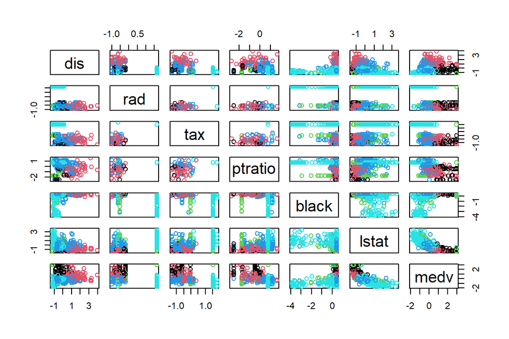

```r
pairs(boston_scaled[8:14], col = km$cluster)# perform plotting in two parts so that plots are easier to look at
```

From the plots above, we can see the clustering in different colours. Some clusters are very clearly separated, but in other cases clusters are on top of each other. So I am not quite sure what would be the most optimal number of clusters in this case.

# 5.Dimensionality reduction techniques

```r
date()
```

```
## [1] "Wed Dec 02 15:17:43 2020"
```

This week I learned something about dimensionality reduction techniques. Below you can find the analysis that was performed, more information about the data that was analyzed and the results I got.

Exercises of week 5 are based on human data. Data Human consists of Human Development Index (HDI) and it considers different aspects of human development,like health, knowledgeability and standards of living. More information from the data can be found [here](http://hdr.undp.org/en/content/human-development-index-hdi).

```r
human <- read.table("http://s3.amazonaws.com/assets.datacamp.com/production/course_2218/datasets/human2.txt", sep=",", header=TRUE)
```

```r
library(GGally); library(corrplot);library(tidyr); library(dplyr); library(ggplot2)
```

#### Graphical overview

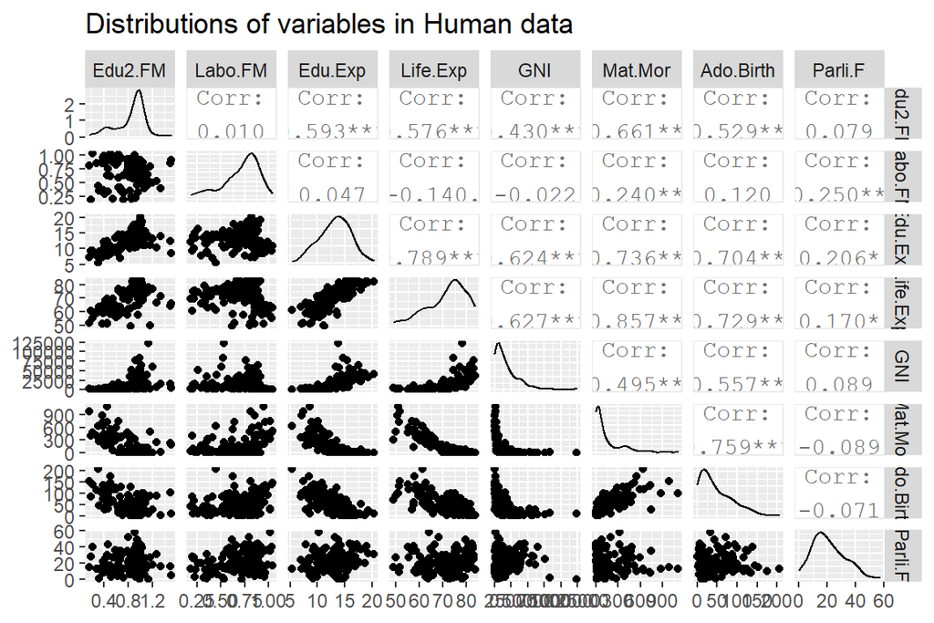

```r
ggpairs(human) + ggtitle("Distributions of variables in Human data")
```

We can see that the distributions of variables Edu2-FM, Labo.FM and Life.exp are on the right, whereas some of the variables (GNI, Mat-Mor,Ado.Birth and Parli.F)are clearly on the left. So for example Maternal mortality ratio (Mat.Mor), Adolescent birth rate (Ado.Birth) and Gross National Income per capita (GNI) are quite low in most of the countries. Expected years of schooling (Edu.exp) is somehow normally distributed and mean value is 13 years, so quite high. And for example Life expectancy at birth (Life.Exp) is clearly on the right, so it is very good in most of the countries. Proportion of females versus males with at least secondary education (Edu2.FM) looks also quite good, mean value is 0.85, so it is almost equal, on average males have a bit more often at least secondary education. And if we look at the Proportion of females versus males in the labour force (Labo.FM), it is similar to education, mean value is a bit lower than is education 0.70, so a bit higher portion of males works compared to females. Distribution of Percetange of female representatives in parliament (Parli.F) is also on the left, so there are not so many females in parliaments around the world, on average 20 %. From the summary we can see the mean, median, min and max values of all the variables and also quantiles.

```r
summary(human)
```

```
##     Edu2.FM          Labo.FM          Edu.Exp         Life.Exp
##  Min.   :0.1717   Min.   :0.1857   Min.   : 5.40   Min.   :49.00
##  1st Qu.:0.7264   1st Qu.:0.5984   1st Qu.:11.25   1st Qu.:66.30
##  Median :0.9375   Median :0.7535   Median :13.50   Median :74.20
##  Mean   :0.8529   Mean   :0.7074   Mean   :13.18   Mean   :71.65
##  3rd Qu.:0.9968   3rd Qu.:0.8535   3rd Qu.:15.20   3rd Qu.:77.25
##  Max.   :1.4967   Max.   :1.0380   Max.   :20.20   Max.   :83.50
##       GNI            Mat.Mor         Ado.Birth         Parli.F
##  Min.   :   581   Min.   :   1.0   Min.   :  0.60   Min.   : 0.00
##  1st Qu.:  4198   1st Qu.:  11.5   1st Qu.: 12.65   1st Qu.:12.40
##  Median : 12040   Median :  49.0   Median : 33.60   Median :19.30
##  Mean   : 17628   Mean   : 149.1   Mean   : 47.16   Mean   :20.91
##  3rd Qu.: 24512   3rd Qu.: 190.0   3rd Qu.: 71.95   3rd Qu.:27.95
##  Max.   :123124   Max.   :1100.0   Max.   :204.80   Max.   :57.50
```

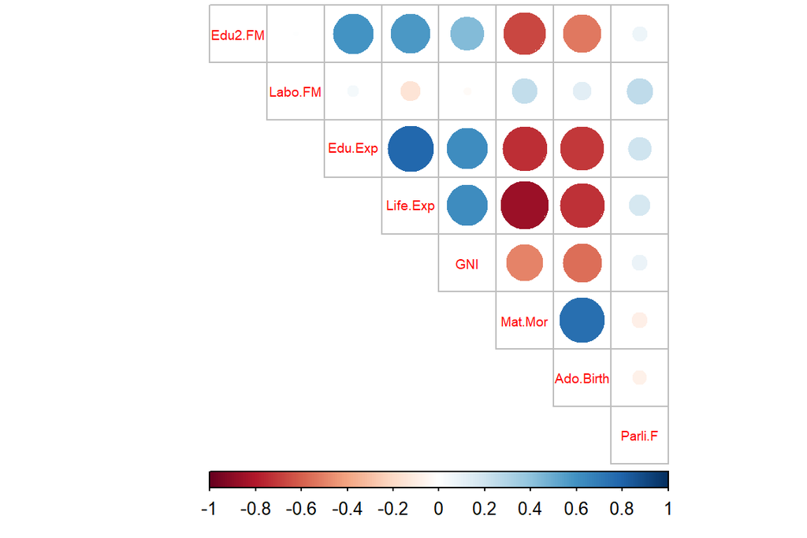

```r
cor(human)%>%corrplot(method="circle",type = "upper", cl.pos = "b", tl.pos = "d", tl.cex = 0.6 )
```

From the correlation plot, we can see the relationships between the variables. Maternal mortality ratio (Mat.Mor) and Life expectancy at birth (Life.Exp) have the highest correlation (-0.857). There are also other significant correlation for example between Expected years of schooling (Edu.exp) and Life expectancy at birth (Life.Exp), Expected years of schooling (Edu.exp and Maternal mortality ratio (Mat.Mor) and Adolescent birth rate (Ado.Birth) and Maternal mortality ratio (Mat.Mor). Variables Proportion of females versus males in the labour force (Labo.FM) and Percetange of female representatives in parliament (Parli.F) don´t have significant correlations between other variables. But they have small positive correlation between each other.

```r
cor(human)
```

```
##                Edu2.FM      Labo.FM     Edu.Exp   Life.Exp         GNI
## Edu2.FM    1.000000000  0.009564039  0.59325156  0.5760299  0.43030485
## Labo.FM    0.009564039  1.000000000  0.04732183 -0.1400125 -0.02173971
## Edu.Exp    0.593251562  0.047321827  1.00000000  0.7894392  0.62433940
## Life.Exp   0.576029853 -0.140012504  0.78943917  1.0000000  0.62666411
## GNI        0.430304846 -0.021739705  0.62433940  0.6266641  1.00000000
## Mat.Mor   -0.660931770  0.240461075 -0.73570257 -0.8571684 -0.49516234
## Ado.Birth -0.529418415  0.120158862 -0.70356489 -0.7291774 -0.55656208
## Parli.F    0.078635285  0.250232608  0.20608156  0.1700863  0.08920818
##              Mat.Mor  Ado.Birth     Parli.F
## Edu2.FM   -0.6609318 -0.5294184  0.07863528
## Labo.FM    0.2404611  0.1201589  0.25023261
## Edu.Exp   -0.7357026 -0.7035649  0.20608156
## Life.Exp  -0.8571684 -0.7291774  0.17008631
## GNI       -0.4951623 -0.5565621  0.08920818
## Mat.Mor    1.0000000  0.7586615 -0.08944000
## Ado.Birth  0.7586615  1.0000000 -0.07087810
## Parli.F   -0.0894400 -0.0708781  1.00000000
```

#### PCA

First I will perform principal component analysis (PCA) on the not standardized human data.

```r
pca_human <- prcomp(human)
```

```r
# creating and print out a summary of pca_human_std
s1 <- summary(pca_human)
s1
```

```
## Importance of components:
##                              PC1      PC2   PC3   PC4   PC5   PC6    PC7    PC8
## Standard deviation     1.854e+04 185.5219 25.19 11.45 3.766 1.566 0.1912 0.1591
## Proportion of Variance 9.999e-01   0.0001  0.00  0.00 0.000 0.000 0.0000 0.0000
## Cumulative Proportion  9.999e-01   1.0000  1.00  1.00 1.000 1.000 1.0000 1.0000
```

```r
# getting rounded percetanges of variance captured by each PC
pca_pr1 <- round(100*s1$importance[2, ], digits = 1)
pca_pr1
```

```
## PC1 PC2 PC3 PC4 PC5 PC6 PC7 PC8
## 100   0   0   0   0   0   0   0
```

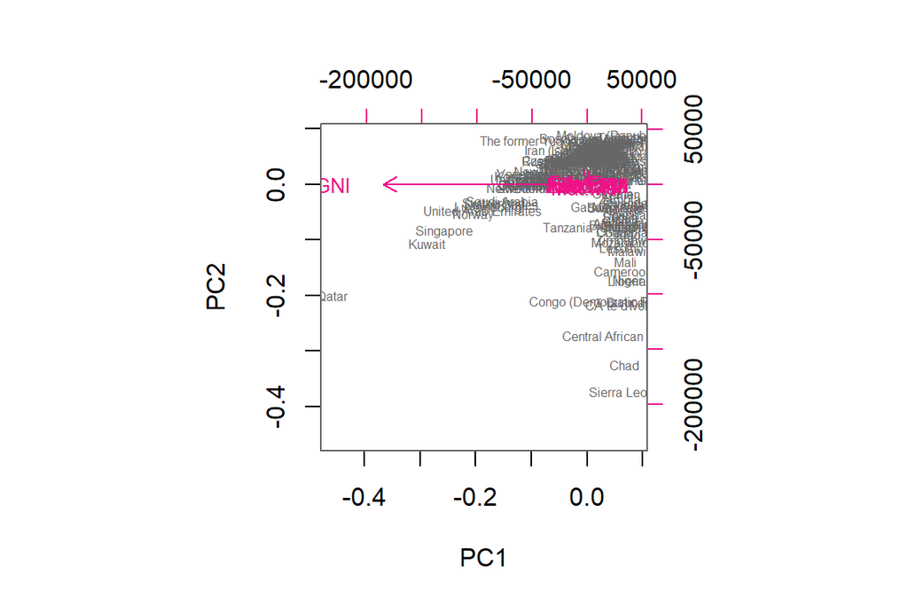

```r
biplot(pca_human, choices = 1:2, cex = c(0.5, 0.8), col = c("grey40", "deeppink2"))
```

From the summary of rounded percetanges of variance, we can see that PC1 explains 100 % of the variance and others are 0. So now it seems like Gross National Income per capita (GNI) is the only variable explaining the variance, and it is pointing in the same direction as PC1 so it is contributing that dimension.

Next I will standardize the variables and repeat the above analysis.

```r
human_std <- scale(human)
summary(human_std)
```

```
##     Edu2.FM           Labo.FM           Edu.Exp           Life.Exp
##  Min.   :-2.8189   Min.   :-2.6247   Min.   :-2.7378   Min.   :-2.7188
##  1st Qu.:-0.5233   1st Qu.:-0.5484   1st Qu.:-0.6782   1st Qu.:-0.6425
##  Median : 0.3503   Median : 0.2316   Median : 0.1140   Median : 0.3056
##  Mean   : 0.0000   Mean   : 0.0000   Mean   : 0.0000   Mean   : 0.0000
##  3rd Qu.: 0.5958   3rd Qu.: 0.7350   3rd Qu.: 0.7126   3rd Qu.: 0.6717
##  Max.   : 2.6646   Max.   : 1.6632   Max.   : 2.4730   Max.   : 1.4218
##       GNI             Mat.Mor          Ado.Birth          Parli.F
##  Min.   :-0.9193   Min.   :-0.6992   Min.   :-1.1325   Min.   :-1.8203
##  1st Qu.:-0.7243   1st Qu.:-0.6496   1st Qu.:-0.8394   1st Qu.:-0.7409
##  Median :-0.3013   Median :-0.4726   Median :-0.3298   Median :-0.1403
##  Mean   : 0.0000   Mean   : 0.0000   Mean   : 0.0000   Mean   : 0.0000
##  3rd Qu.: 0.3712   3rd Qu.: 0.1932   3rd Qu.: 0.6030   3rd Qu.: 0.6127
##  Max.   : 5.6890   Max.   : 4.4899   Max.   : 3.8344   Max.   : 3.1850
```

```r
pca_human_std <- prcomp(human_std)
```

```r
# creating and print out a summary of pca_human_std
s2 <- summary(pca_human_std)
s2
```

```
## Importance of components:
##                           PC1    PC2     PC3     PC4     PC5     PC6     PC7
## Standard deviation     2.0708 1.1397 0.87505 0.77886 0.66196 0.53631 0.45900
## Proportion of Variance 0.5361 0.1624 0.09571 0.07583 0.05477 0.03595 0.02634
## Cumulative Proportion  0.5361 0.6984 0.79413 0.86996 0.92473 0.96069 0.98702
##                            PC8
## Standard deviation     0.32224
## Proportion of Variance 0.01298
## Cumulative Proportion  1.00000
```

```r
# getting rounded percetanges of variance captured by each PC
pca_pr <- round(100*s2$importance[2, ], digits = 1)
pca_pr
```

```
##  PC1  PC2  PC3  PC4  PC5  PC6  PC7  PC8
## 53.6 16.2  9.6  7.6  5.5  3.6  2.6  1.3
```

```r
# creating object pc_lab to be used as axis labels so that we can see the percentages of PCs
pc_lab <- paste0(names(pca_pr), " (", pca_pr, "%)")
```

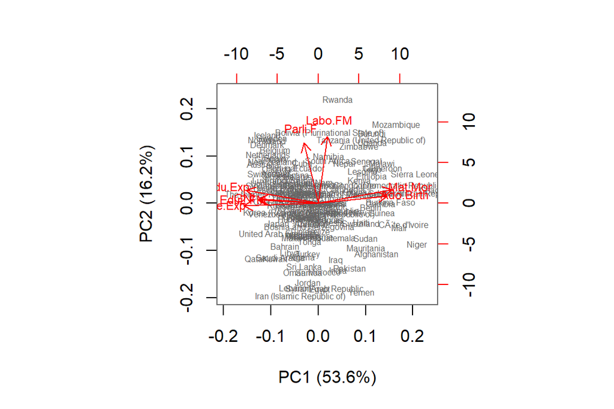

```r
biplot(pca_human_std, cex = c(0.5, 0.7), col = c("grey40", "red"), xlab = pc_lab[1], ylab = pc_lab[2])
```

If we compare non-standardized and standardized PCA-plots, they look totally different. Now there are multiple arrows pointing at different directions. PC1 explains 53.6 % of the variance and PC2 16.2 %. Small angle between arrows means high positive correlation, so there is high positive correlation between variables Maternal mortality ratio (Mat.Mor) and Adolescent birth rate (Ado.Birth) which was seen also earlier in the correlation plot. They have also small angle between PC1 which means also high positive correlation between them and they are contributing that dimension. There are multiple arrows pointing at the opposite direction from (Mat.Mor) and (Ado.Birth). They are also affecting PC1 and correlating with it. There are also very small angles between all of them so they are correlating with each other. Those variables are: Expected years of schooling (Edu.exp), Proportion of females versus males with at least secondary education (Edu2.FM), Life expectancy at birth (Life.Exp) and Gross National Income per capita (GNI). GNI arrow is still pointing in the same direction as in the non-standardized PCA-plot. There are still two variables Proportion of females versus males in the labour force (Labo.FM) and Percetange of female representatives in parliament (Parli.F) which are pointing upwards, in the same direction as PC2 so they are correlating with it. There is clear angle between them, so the correlation between those variables is smaller but still existing. But angles between the arrows pointing up versus others pointing horizontally are quite big, which means that there is no correlation between them. Almost all the lenghts of the arrows are equal, which means that the standard deviations are quite equal.

I think the first two PC dimensions explain well the distributions of different countries based on different variables. If we look at the standardized human data PCA plot, we can see that in the right side, there are a lot of African countries, whereas on the left side there are Westerns countries and the Nordic countries in the left upper corner. And also in the bottom of the plot are mainly Arabic countries. We all know that there are differences between those countries which are also shown in this plot. For example in the African countries Maternal mortality ratio (Mat.Mor) and Adolescent birth rate (Ado.Birth) are higher, in the Western countries Expected years of schooling (Edu.exp), Proportion of females versus males with at least secondary education (Edu2.FM), Life expectancy at birth (Life.Exp) and Gross National Income per capita (GNI) are higher and also in the Nordic countries the Percentage of female representatives in parliament (Parli.F) is higher as we know from Finland for example. Whereas in some of the Arabic countries the situation is opposite considering the Percentage of female representatives in parliament. But there are also exceptions like Rwanda in the up.

#### Tea dataset and MCA analysis

```r
library(FactoMineR)
```

In this last part of exercise 5, I will explore the dataset Tea from FactoMineR-library. Then I will perform Multiple Correspondence Analysis on the data.

```r
data(tea)
str(tea)
```

```
## 'data.frame':    300 obs. of  36 variables:
##  $ breakfast       : Factor w/ 2 levels "breakfast","Not.breakfast": 1 1 2 2 1 2 1 2 1 1 ...
##  $ tea.time        : Factor w/ 2 levels "Not.tea time",..: 1 1 2 1 1 1 2 2 2 1 ...
##  $ evening         : Factor w/ 2 levels "evening","Not.evening": 2 2 1 2 1 2 2 1 2 1 ...
##  $ lunch           : Factor w/ 2 levels "lunch","Not.lunch": 2 2 2 2 2 2 2 2 2 2 ...
##  $ dinner          : Factor w/ 2 levels "dinner","Not.dinner": 2 2 1 1 2 1 2 2 2 2 ...
##  $ always          : Factor w/ 2 levels "always","Not.always": 2 2 2 2 1 2 2 2 2 2 ...
##  $ home            : Factor w/ 2 levels "home","Not.home": 1 1 1 1 1 1 1 1 1 1 ...
##  $ work            : Factor w/ 2 levels "Not.work","work": 1 1 2 1 1 1 1 1 1 1 ...
##  $ tearoom         : Factor w/ 2 levels "Not.tearoom",..: 1 1 1 1 1 1 1 1 1 2 ...
##  $ friends         : Factor w/ 2 levels "friends","Not.friends": 2 2 1 2 2 2 1 2 2 2 ...
##  $ resto           : Factor w/ 2 levels "Not.resto","resto": 1 1 2 1 1 1 1 1 1 1 ...
##  $ pub             : Factor w/ 2 levels "Not.pub","pub": 1 1 1 1 1 1 1 1 1 1 ...
##  $ Tea             : Factor w/ 3 levels "black","Earl Grey",..: 1 1 2 2 2 2 2 1 2 1 ...
##  $ How             : Factor w/ 4 levels "alone","lemon",..: 1 3 1 1 1 1 1 3 3 1 ...
```

[output cut: 22 more lines]

```r
dim(tea)#300 rows and 36 columns
```

```
## [1] 300  36
```

There are 300 observations of 36 variables in the tea data. Data has variables that consider when, where and how people drink tea and different kind of experiences related to drinking tea.

#### Graphical overview

Here are the bar plots of all the variables. They are shown in multiple pictures, because that way they are easier to read

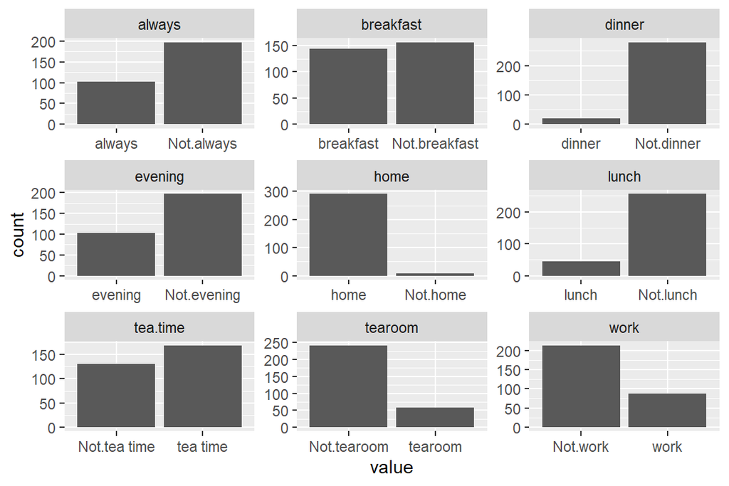

```r
gather(tea[1:9]) %>% ggplot(aes(value)) + facet_wrap("key", scales = "free") + geom_bar()
```

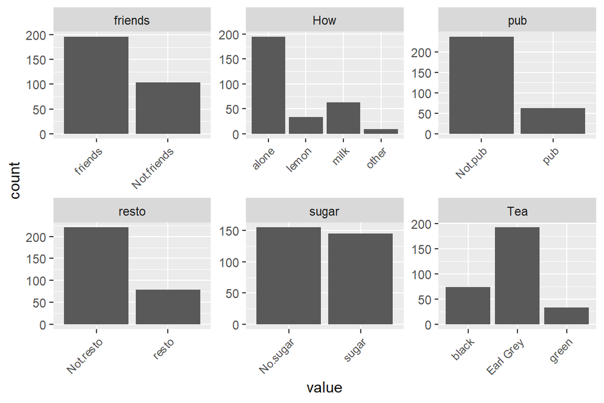

```r
gather(tea[10:15]) %>% ggplot(aes(value)) + facet_wrap("key", scales = "free") + geom_bar() +theme(axis.text.x = element_text(angle = 45, hjust = 1, size = 8))
```

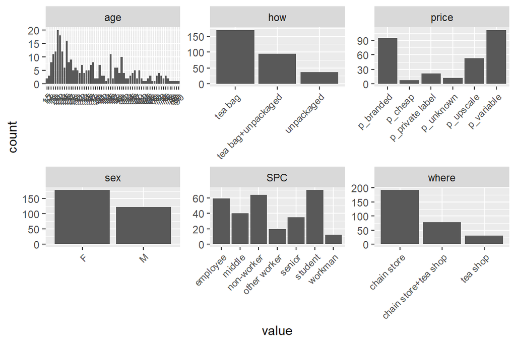

```r
gather(tea[16:21]) %>% ggplot(aes(value)) + facet_wrap("key", scales = "free") + geom_bar() +theme(axis.text.x = element_text(angle = 45, hjust = 1, size = 8))
```

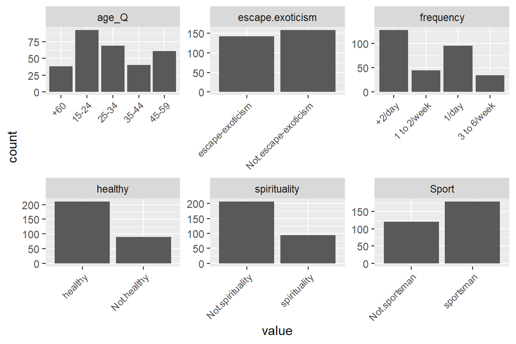

```r
gather(tea[22:27]) %>% ggplot(aes(value)) + facet_wrap("key", scales = "free") + geom_bar() +theme(axis.text.x = element_text(angle = 45, hjust = 1, size = 8))
```

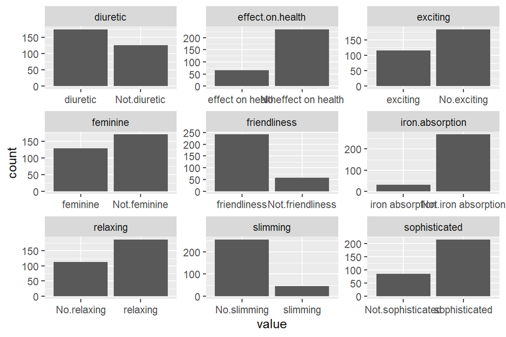

```r
gather(tea[28:36]) %>% ggplot(aes(value)) + facet_wrap("key", scales = "free") + geom_bar()
```

I chose variables Tea, How, sex, sugar, frequency, age_Q and effect.on.health for the MCA analysis.

```r
# column names to keep in the dataset
keep_columns <- c("Tea", "How", "sex", "sugar", "frequency", "age_Q", "effect.on.health")
```

```r
# select the 'keep_columns' to create a new dataset
tea_time <- dplyr::select(tea, one_of(keep_columns))
summary(tea_time)
```

```
##         Tea         How      sex          sugar           frequency
##  black    : 74   alone:195   F:178   No.sugar:155   1/day      : 95
##  Earl Grey:193   lemon: 33   M:122   sugar   :145   1 to 2/week: 44
##  green    : 33   milk : 63                          +2/day     :127
##                  other:  9                          3 to 6/week: 34
##
##    age_Q               effect.on.health
##  15-24:92   effect on health   : 66
##  25-34:69   No.effect on health:234
##  35-44:40
##  45-59:61
##  +60  :38
```

```r
str(tea_time)
```

```
## 'data.frame':    300 obs. of  7 variables:
##  $ Tea             : Factor w/ 3 levels "black","Earl Grey",..: 1 1 2 2 2 2 2 1 2 1 ...
##  $ How             : Factor w/ 4 levels "alone","lemon",..: 1 3 1 1 1 1 1 3 3 1 ...
##  $ sex             : Factor w/ 2 levels "F","M": 2 1 1 2 2 2 2 1 2 2 ...
##  $ sugar           : Factor w/ 2 levels "No.sugar","sugar": 2 1 1 2 1 1 1 1 1 1 ...
##  $ frequency       : Factor w/ 4 levels "1/day","1 to 2/week",..: 1 1 3 1 3 1 4 2 3 3 ...
##  $ age_Q           : Factor w/ 5 levels "15-24","25-34",..: 3 4 4 1 4 1 3 3 3 3 ...
##  $ effect.on.health: Factor w/ 2 levels "effect on health",..: 2 2 2 2 2 2 2 2 2 2 ...
```

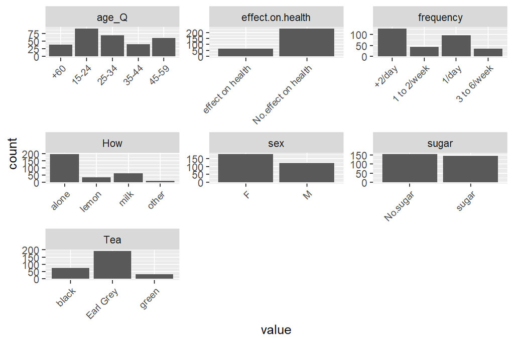

```r
gather(tea_time) %>% ggplot(aes(value)) + facet_wrap("key", scales = "free") + geom_bar() +theme(axis.text.x = element_text(angle = 45, hjust = 1, size = 8))
```

```r
mca <- MCA(tea_time, graph = FALSE)
summary(mca)
```

```
##
## Call:
## MCA(X = tea_time, graph = FALSE)
##
##
## Eigenvalues
##                        Dim.1   Dim.2   Dim.3   Dim.4   Dim.5   Dim.6   Dim.7
## Variance               0.242   0.210   0.184   0.170   0.159   0.154   0.149
## % of var.             11.286   9.818   8.592   7.943   7.417   7.170   6.952
## Cumulative % of var.  11.286  21.103  29.696  37.639  45.056  52.226  59.178
##                        Dim.8   Dim.9  Dim.10  Dim.11  Dim.12  Dim.13  Dim.14
## Variance               0.134   0.130   0.126   0.123   0.109   0.090   0.083
## % of var.              6.243   6.076   5.893   5.738   5.104   4.222   3.893
## Cumulative % of var.  65.421  71.497  77.391  83.128  88.232  92.455  96.348
##                       Dim.15
## Variance               0.078
## % of var.              3.652
## Cumulative % of var. 100.000
##
## Individuals (the 10 first)
##              Dim.1    ctr   cos2    Dim.2    ctr   cos2    Dim.3    ctr   cos2
## 1         |  0.016  0.000  0.000 |  0.546  0.473  0.139 |  0.155  0.044  0.011
## 2         |  0.706  0.688  0.236 |  0.271  0.116  0.035 | -0.499  0.450  0.118
## 3         |  0.490  0.331  0.203 | -0.573  0.520  0.277 | -0.450  0.366  0.171
## 4         | -0.669  0.618  0.377 | -0.114  0.021  0.011 | -0.024  0.001  0.000
## 5         |  0.301  0.125  0.070 | -0.146  0.034  0.016 | -0.476  0.410  0.175
## 6         | -0.280  0.108  0.067 | -0.186  0.055  0.030 | -0.261  0.123  0.058
## 7         |  0.113  0.018  0.005 |  0.042  0.003  0.001 |  0.112  0.023  0.005
## 8         |  0.508  0.356  0.086 |  0.303  0.145  0.030 |  0.371  0.249  0.046
## 9         |  0.248  0.085  0.029 |  0.203  0.065  0.019 | -0.010  0.000  0.000
## 10        |  0.617  0.526  0.189 |  0.233  0.086  0.027 |  0.142  0.036  0.010
##
## 1         |
## 2         |
## 3         |
## 4         |
## 5         |
## 6         |
## 7         |
## 8         |
```

[output cut: 21 more lines]

```
## milk       -0.158   0.407   0.007  -1.408 |
## other       2.464  14.128   0.188   7.492 |
## F           0.032   0.048   0.002   0.671 |
## M          -0.047   0.069   0.002  -0.671 |
## No.sugar   -0.344   4.735   0.126  -6.144 |
##
## Categorical variables (eta2)
##                    Dim.1 Dim.2 Dim.3
## Tea              | 0.342 0.220 0.264 |
## How              | 0.141 0.167 0.275 |
## sex              | 0.103 0.453 0.002 |
## sugar            | 0.448 0.013 0.126 |
## frequency        | 0.179 0.123 0.202 |
## age_Q            | 0.475 0.419 0.414 |
## effect.on.health | 0.005 0.076 0.006 |
```

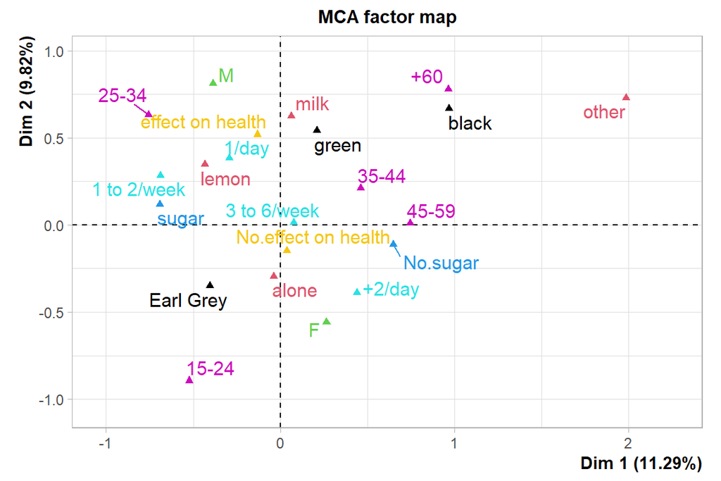

```r
plot(mca, invisible=c("ind"), habillage = "quali")
```

Here are some thoughts about the relationships between variables in tea data based on MCA factor map. Distances between variables in MCA plot tells about the similarity of the variables, closer they are to each other more similar they are. For example females (F) and males (M) are quite far away from each other so they are different. +60 and black are close to each other so maybe older people usually drink black tea. Green is also quite close to effect on health so maybe green tea has an effect on health compared to black tea for example. Age groups 35-44 and 45-59 are quite close to each other so maybe they have quite similar habits. Whereas 15-24 are far away from everything. Females (F) are close to +2/day, so maybe they drink tea more often. No sugar is closer to females and older people and sugar is closer to males and younger people so maybe this tells something about who uses sugar in their tea more often.

# 6. Analysis of longitudinal data

```r
date()
```

```
## [1] "Wed Dec 02 15:18:03 2020"
```

This week I learned something about the analysis of longitudinal data. Below you can find the analysis that was performed, more information about the data that was analyzed and the results I got.

Useful libraries:

```r
library(dplyr)
library(tidyr)
library(ggplot2)
```

### Analysis of RATS data

RATS data consists of results from a nutrition study conducted in three groups of rats which were put on a different diet and their body weights were recorded repeatedly over a nine week period (Crowder and Hand 1990). And now I will look if there are any differences between those groups.

Here is the RATS data that was wrangled in a long form:

```r
RATSL <- read.table("~/R/IODS-course/IODS-project/Data/RATSL.txt", sep = " ", header=TRUE)
glimpse(RATSL)
```

```
## Rows: 176
## Columns: 5
## $ ID     <int> 1, 2, 3, 4, 5, 6, 7, 8, 9, 10, 11, 12, 13, 14, 15, 16, 1, 2,...
## $ Group  <int> 1, 1, 1, 1, 1, 1, 1, 1, 2, 2, 2, 2, 3, 3, 3, 3, 1, 1, 1, 1, ...
## $ WD     <chr> "WD1", "WD1", "WD1", "WD1", "WD1", "WD1", "WD1", "WD1", "WD1...
## $ Weight <int> 240, 225, 245, 260, 255, 260, 275, 245, 410, 405, 445, 555, ...
## $ Time   <int> 1, 1, 1, 1, 1, 1, 1, 1, 1, 1, 1, 1, 1, 1, 1, 1, 8, 8, 8, 8, ...
```

Variables ID and Group have to be changed to factors again.

```r
RATSL$ID <- factor(RATSL$ID)
RATSL$Group <- factor(RATSL$Group)
glimpse(RATSL)
```

```
## Rows: 176
## Columns: 5
## $ ID     <fct> 1, 2, 3, 4, 5, 6, 7, 8, 9, 10, 11, 12, 13, 14, 15, 16, 1, 2,...
## $ Group  <fct> 1, 1, 1, 1, 1, 1, 1, 1, 2, 2, 2, 2, 3, 3, 3, 3, 1, 1, 1, 1, ...
## $ WD     <chr> "WD1", "WD1", "WD1", "WD1", "WD1", "WD1", "WD1", "WD1", "WD1...
## $ Weight <int> 240, 225, 245, 260, 255, 260, 275, 245, 410, 405, 445, 555, ...
## $ Time   <int> 1, 1, 1, 1, 1, 1, 1, 1, 1, 1, 1, 1, 1, 1, 1, 1, 8, 8, 8, 8, ...
```